# RespirationRates_biovolume_estimation

# (2) Estimate size relationships

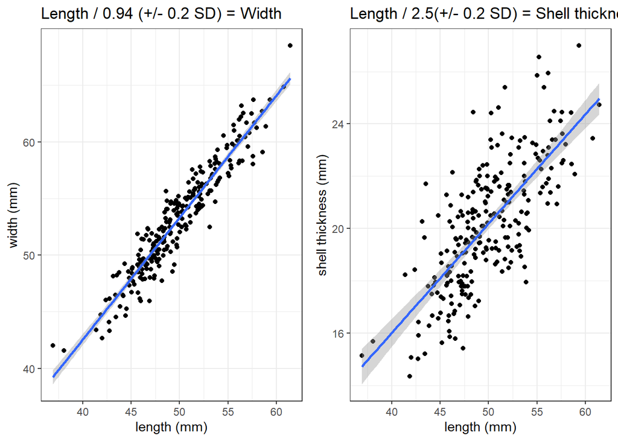

```r
# since we only have shell length, what is the average relationship of length to width and thickness to generate volume?
Gurr2021_size.relationships <- Gurr2021_biovol %>%
  dplyr::filter(species %in% 'Ai') %>%
  dplyr::select(c('pre_biovolume_mL', 'length_mm', 'width_mm', 'thickness_mm')) %>%
  dplyr::mutate(length.biov = (length_mm/pre_biovolume_mL)) %>%
  dplyr::mutate(length.width = (length_mm/width_mm)) %>%
  dplyr::mutate(length.thick = (length_mm/thickness_mm)) %>%
  dplyr::mutate(length.cubed = (length_mm^3)) %>%
  dplyr::mutate(lengthcubed.biov = (length.cubed/pre_biovolume_mL))


Length.Width <- Gurr2021_size.relationships[!is.na(Gurr2021_size.relationships$length.width),] %>%
    dplyr::filter(!thickness_mm > 50) %>%
    summarySE(measurevar="length.width")  # mean = 0.9387522    stdev = 0.02717396  - consistent relationship


length_width <- Gurr2021_size.relationships %>%
  dplyr::filter(!thickness_mm > 50) %>%
   ggplot(aes(x=length_mm, y=width_mm)) + # , color = as.factor(site))
   geom_point() +
   xlab("length (mm)") +
   ylab("width (mm)") +
   ggtitle("Length / 0.94 (+/- 0.2 SD) = Width") +
   geom_smooth(method='lm', formula= y~x) +
   theme_bw()


Length.Thickness <- Gurr2021_size.relationships[!is.na(Gurr2021_size.relationships$length.thick),] %>%
  dplyr::filter(!thickness_mm > 50) %>%
  summarySE(measurevar="length.thick")  # mean = 2.487012   stdev = 0.2249636   - highly variable relationship

length_thickness <- Gurr2021_size.relationships %>%
  dplyr::filter(!thickness_mm > 50) %>%
   ggplot(aes(x=length_mm, y=thickness_mm)) + # , color = as.factor(site))
   geom_point() +
   xlab("length (mm)") +
   ggtitle("Length / 2.5(+/- 0.2 SD) = Shell thickness") +
   ylab("shell thickness (mm)") +

   geom_smooth(method='lm', formula= y~x) +
   theme_bw()

ggarrange(length_width, length_thickness)
```

```r
Length.biovol <- Gurr2021_size.relationships[!is.na(Gurr2021_size.relationships$length.biov),] %>% summarySE(measurevar="length.biov")  # mean = 2.55471    stdev = 0.4976332

Lengthcubed.Biovol <- Gurr2021_size.relationships[!is.na(Gurr2021_size.relationships$lengthcubed.biov),] %>%
    dplyr::filter(!thickness_mm > 50) %>%
    summarySE(measurevar="lengthcubed.biov")  # mean = 5815.944     stdev = 927.8011

927.8011/5815.944 # 0.1595272 %
```

```
## [1] 0.1595272
```

# (3) Actual vs. Calculated biovolume - our data

Volume of a spherical cap (1/6)πh(3a2 + h2) == Vcap

- h = height
  - for a scallop is 1/2*shell thickness
  - calc shell thickness as length / 2.5
- a = radius from the cap bottom
  - for scallop shell is 1/2*length from hinge
- R = radius from the center of the sphere - not applicable for the known measurements of the scallop
- Vcap*2 = estaimted biovolume of a live scallop, accounting for both valves

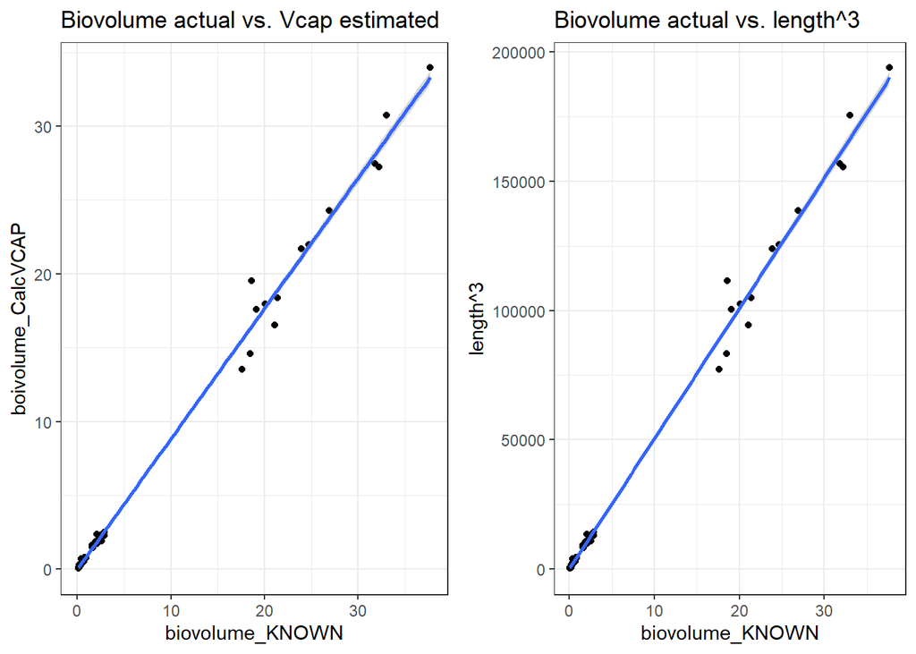

```r
# ::::::::::::::::::::::::::::::::::::::::::::::::::::::::::::::::::::::::::::::::::::
# Now to test with the current data in this study..


# volume of a spherical cap (1/3)πh2(3R - h) or (1/6)πh(3a2 + h2)
# h = height (for a scallop is 1/2*shell thickness)
# a = radius from the cap bottom (for scallop shell is 1/2*length from hinge)
# R = radius from the center of the sphere - not applicable for the known measurments of the scallop
Reference_resp_sizeOM <- Reference_resp_size[!is.na(Reference_resp_size$Biovolume_g_in_sw),] %>%
  dplyr::filter(!Biovolume_g_in_sw %in% '<add here>') %>%
  dplyr::mutate(Length_mm = as.numeric(Length_um/1000)) %>%
  dplyr::select(c('Date','pH','Length_mm','Biovolume_g_in_sw')) %>%
  dplyr::mutate(Thickness_mm_estimate = Length_mm / 2.5) %>% # from data taken in Gurr et al. 2021 (adult A.irradians)
  dplyr::mutate(h = as.numeric(Thickness_mm_estimate / 2)) %>% # divide by 2 fo the calculation of a single cap
  dplyr::mutate(a = as.numeric((Length_mm/0.97)/2)) %>% # note the length is 0.94 of the width in adult scallops (Gurr et al. 2021 data)
  dplyr::mutate(Cap_vol_L = ((1/6)*3.14*h)*(3*(a^2) + h^2)) %>%
  dplyr::mutate(Biovol_estimate_mL3 = (Cap_vol_L*2)/1000)

# colnames(Reference_resp_sizeOM)
Biov_actual_Vcap <- Reference_resp_sizeOM %>%
   ggplot(aes(x=as.numeric(Biovolume_g_in_sw), y=as.numeric(Biovol_estimate_mL3))) + # color = as.factor(pH))) +
   geom_point() +
   xlab("biovolume_KNOWN") +
   ylab("boivolume_CalcVCAP") +
   ggtitle("Biovolume actual vs. Vcap estimated") +
   geom_smooth(method='lm', formula= y~x) +
   theme_bw()
# Biov_actual_Vcap


Biov_length3_regression <- Reference_resp_sizeOM %>%
   dplyr::mutate(length_cubed = (Length_mm^3)) %>%
   ggplot(aes(x=as.numeric(Biovolume_g_in_sw), y=as.numeric(length_cubed))) + # color = as.factor(pH))) +
   geom_point() +
   xlab("biovolume_KNOWN") +
   ylab("length^3") +
   ggtitle("Biovolume actual vs. length^3") +
   geom_smooth(method='lm', formula= y~x) +
   theme_bw()
# Biov_length3_regression

ggarrange(Biov_actual_Vcap, Biov_length3_regression)
```